# Macro Signals and U.S. Equity Returns

A release-aware, out-of-sample classification study

Som Tripathi

PORTFOLIO CASE STUDY

Can the unemployment rate, combined with recent market behavior, improve forecasts of next-month S&P 500 direction?

## 1 Executive summary

55.7%Out-of-sample accuracy

68.9%Baseline accuracy

0.49Out-of-sample ROC AUC

122Test observations

This study uses monthly observations from **March 2000** through **April 2026**. A logistic regression is trained through **December 2015** and evaluated only on later observations.

> **Bottom line.** The model did not improve on the historical up-rate baseline; its ROC AUC was 0.49. The result is useful precisely because the benchmark is difficult to beat: U.S. equity months are positive more often than they are negative, so headline accuracy without a baseline can be misleading.

## 2 Research design

The unit of analysis is one calendar month. At the close of month $t$, the model uses:

- the latest unemployment rate that would have been published by then;
- the latest published monthly change in unemployment;
- the S&P 500 return during month $t$; and
- annualized daily volatility during month $t$.

It predicts whether the S&P 500 return in month $t+1$ will be positive.

| Component | Choice | Reason |
| --- | --- | --- |
| Target | Next-month S&P 500 direction | Clear binary outcome with an investable forecast horizon |
| Macro timing | Unemployment lagged one month | Avoids using a value before its public release |
| Validation | Chronological holdout | Preserves ordering and prevents random-split leakage |
| Baseline | Training-period up rate | Measures whether the model beats the market’s class imbalance |
| Metrics | Accuracy, balanced accuracy, Brier score, ROC AUC | Covers classification and probability quality |

### 2.1 Why publication timing matters

The unemployment rate for a given month is generally released during the following month. Treating month $t$’s unemployment rate as known during month $t$ creates look-ahead bias. This analysis conservatively maps each unemployment observation to the next calendar month, when it is available to a forecaster.

## 3 Data and preparation

The repository includes versioned raw-data snapshots from two public sources:

- [Yahoo Finance](https://finance.yahoo.com/quote/%5EGSPC/history) for daily adjusted S&P 500 prices (`^GSPC`);
- [FRED](https://fred.stlouisfed.org/series/UNRATE) for the monthly U.S. unemployment rate (`UNRATE`).

By default, the report renders from those snapshots so the analysis remains available when an upstream service is unavailable. Setting `REFRESH_DATA=true` attempts a live refresh and updates the snapshots when successful. This render used **Versioned Yahoo Finance snapshot** and **Versioned FRED snapshot**.

The current, incomplete market month is excluded. Monthly returns are compounded from daily log returns, while volatility is the standard deviation of daily log returns annualized with $\sqrt{252}$.

| Series | Start | End | Observations |
| --- | --- | --- | --- |
| S&P 500 daily prices | 2000-01-03 | 2026-05-29 | 6641 |
| U.S. unemployment rate | 2000-01 | 2026-05 | 317 |
| Release-aware model sample | 2000-03 | 2026-04 | 312 |

```r
sp500_daily <- sp500_raw %>%
  arrange(date) %>%
  mutate(daily_log_return = log(adjusted / lag(adjusted))) %>%
  filter(!is.na(daily_log_return))

sp500_monthly <- sp500_daily %>%
  mutate(month_date = floor_date(date, "month")) %>%
  group_by(month_date) %>%
  summarise(
    monthly_log_return = sum(daily_log_return),
    monthly_return = exp(monthly_log_return) - 1,
    annualized_volatility = sd(daily_log_return) * sqrt(252),
    n_trading_days = n(),
    .groups = "drop"
  )
```

### 3.1 Market history

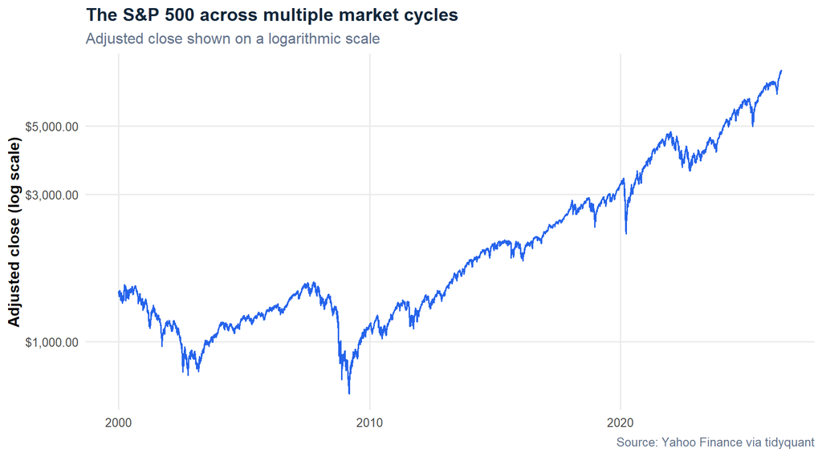

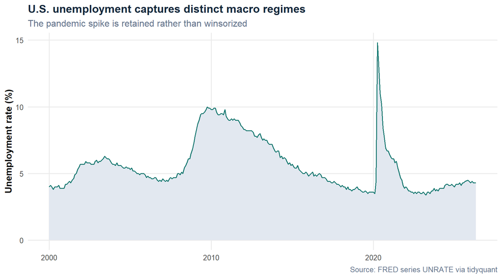

### 3.2 Descriptive relationships

These plots are descriptive, not causal. They show the contemporaneous relationship between unemployment conditions and market behavior without claiming that unemployment alone drives returns.

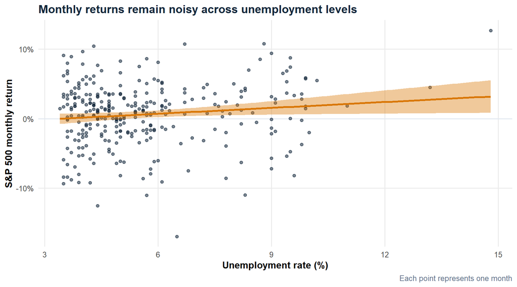

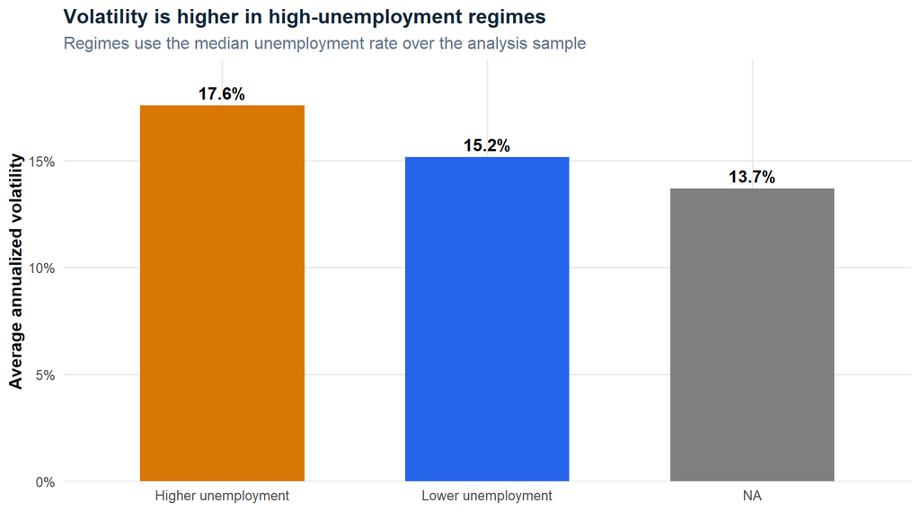

## 4 Modeling

### 4.1 Feature engineering and split

All transformations are calculated in chronological order. Predictor standardization is fit on the training sample and then applied unchanged to the test sample.

```r
feature_names <- c(
  "available_unemployment",
  "available_unemp_change",
  "monthly_return",
  "annualized_volatility"
)

train_data <- model_data %>%
  filter(month_date <= floor_date(as.Date(params$train_end), "month"))

test_data <- model_data %>%
  filter(month_date > floor_date(as.Date(params$train_end), "month"))

feature_center <- vapply(train_data[feature_names], mean, numeric(1))
feature_scale <- vapply(train_data[feature_names], sd, numeric(1))

train_model <- standardize_features(train_data, feature_center, feature_scale)
test_model <- standardize_features(test_data, feature_center, feature_scale)

logit_fit <- glm(
  next_month_up ~ available_unemployment + available_unemp_change +
    monthly_return + annualized_volatility,
  data = train_model,
  family = binomial()
)
```

### 4.2 Coefficient interpretation

Because predictors are standardized, each coefficient represents a one-standard-deviation increase in that feature while the others are held constant. Confidence intervals that cross an odds ratio of 1 indicate weak evidence of a stable directional relationship.

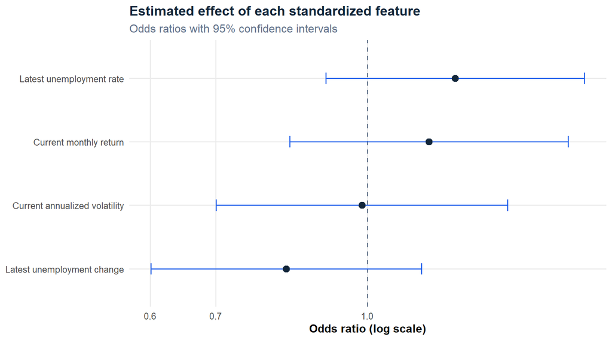

## 5 Out-of-sample evaluation

The model is evaluated from **January 2016** through **April 2026**. The baseline assigns every test observation the positive-month probability observed in the training period.

| metric | Logistic regression | Historical up-rate baseline |
| --- | --- | --- |
| Accuracy | 55.7% | 68.9% |
| Balanced accuracy | 43.4% | 50.0% |
| Brier score | 0.250 | 0.224 |
| ROC AUC | 49.2% | 50.0% |

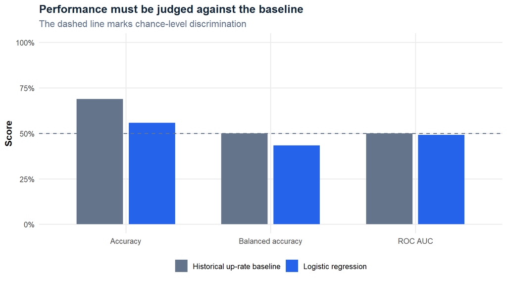

### 5.1 Confusion matrix

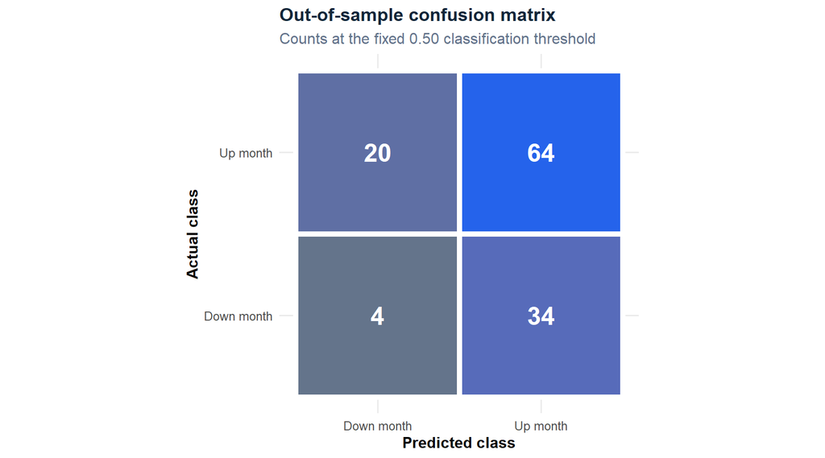

### 5.2 Predicted probability through time

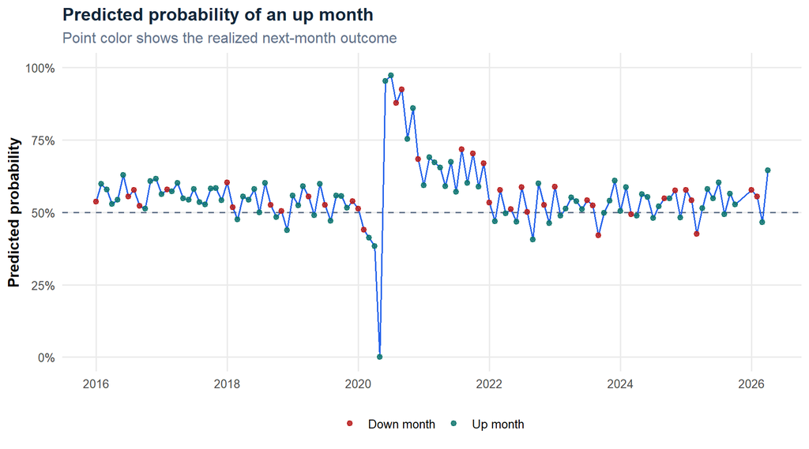

## 6 Conclusions

1. **The evaluation design matters more than the algorithm.** A chronological split, release-aware macro features, and an explicit baseline prevent an optimistic result.
2. **Unemployment is more informative about market conditions than short-horizon direction.** High-unemployment periods coincide with elevated volatility, but that relationship does not automatically translate into reliable next-month forecasts.
3. **A weak predictive result is still a useful research result.** The model provides a transparent benchmark and a foundation for testing richer real-time macro indicators, valuation measures, or walk-forward estimation.

## 7 Limitations and next steps

- FRED observations are revised over time; this report uses the latest vintage rather than a real-time vintage database such as ALFRED.
- The model does not include transaction costs, portfolio sizing, or an investable backtest.
- One fixed train/test split is transparent but does not measure stability across multiple historical windows.
- Statistical significance is not economic significance, and this analysis should not be interpreted as investment advice.

A logical extension would use expanding-window validation and real-time macro vintages, then compare logistic regression with regularized models while preserving the same release-aware feature set.

## 8 Reproducibility

The report was rendered with R **4.5.1**. Package versions are recorded in `renv.lock`; the full analysis pipeline lives in `R/analysis.R`.